# solution2

2024-10-06

# Part 1: Logistic regression

## a) log.likelihood and explanation

- log-likelihood function:
  $$\ell(\beta) = \sum_{i=1}^{n} \left[ y_i (x_i^T \beta) - \log(1 +
  e^{x_i^T \beta}) \right]$$
- explanation:
- With start with a initial estimation of $\beta$ and estimate the loglikelihood.
- Then we need to calculate the gradient or score function which is the first derivative of the log-likelihood function.
- Then we calculate the Hessian, which is the second derivative of the log-likelihood function.
- The updated $\beta$ is
  $$\beta^{(t+1)} = \beta^{(t)} + H(\beta^{(t)})^{-1} s(\beta^{(t)})$$
  , where we move into the direction of the gradient (to maximise) and scale this by the Hessian to adjust for the curvature of the log-likelihood curve.
- Finally, we compare the newly calculated log-likelihood of + 1 and until we reach convergence (difference smaller than $\epsilon$).

## b)

```r
filepath <- "https://www.math.ntnu.no/emner/TMA4315/2018h/mountains"
mount <- read.table(file = filepath, header = TRUE, col.names = c("height",
    "prominence", "fail", "success"))
bin1 = glm(cbind(success, fail) ~ height + prominence, data = mount, family = "binomial")
model_sum1 = summary(bin1)
model_sum1
```

```
##
## Call:
## glm(formula = cbind(success, fail) ~ height + prominence, family = "binomial",
##     data = mount)
##
## Coefficients:
##               Estimate Std. Error z value Pr(>|z|)
## (Intercept)  1.369e+01  1.064e+00  12.861  < 2e-16 ***
## height      -1.635e-03  1.420e-04 -11.521  < 2e-16 ***
## prominence  -1.740e-04  4.554e-05  -3.821 0.000133 ***
## ---
## Signif. codes:  0 '***' 0.001 '**' 0.01 '*' 0.05 '.' 0.1 ' ' 1
##
## (Dispersion parameter for binomial family taken to be 1)
##
##     Null deviance: 715.29  on 112  degrees of freedom
## Residual deviance: 414.68  on 110  degrees of freedom
## AIC: 686.03
##
## Number of Fisher Scoring iterations: 4
```

```r
anova(bin1, test = 'LRT')
```

```
## Analysis of Deviance Table
##
## Model: binomial, link: logit
##
## Response: cbind(success, fail)
##
## Terms added sequentially (first to last)
##
##
##            Df Deviance Resid. Df Resid. Dev  Pr(>Chi)
## NULL                         112     715.29
## height      1  285.986       111     429.30 < 2.2e-16 ***
## prominence  1   14.618       110     414.68 0.0001316 ***
## ---
## Signif. codes:  0 '***' 0.001 '**' 0.01 '*' 0.05 '.' 0.1 ' ' 1
```

```r
exp(13.686)
```

```
## [1] 878525.3
```

```r
exp(-0.001635)
```

```
## [1] 0.9983663
```

```r
exp(-0.000174 )
```

```
## [1] 0.999826
```

#### Interpretation:

- If height and prominence are zero, the odds ratio of succeeding is 878525.3 (= exp(13.686). So, for a mountain with height = 0 and prominence = 0, the chances of reaching the summit are high.
- If the height increases by one meter, the odds ratio is reduced by the factor 0.9983663. So, the chances to reach the summit get lower with every meter a mountain is higher.
- If the prominence increases by one meter, the odds ratio is reduced by the factor 0.999826. So, the chances to reach the summit get lower with every meter of prominence.
- Both parameters seem to reduce the odds ratio not too strongly. But given the fact that the data set only included the highest mountains with heights over 7000 meters, the influence comes through the large numbers in height.

#### Significance:

- The Wald test shows that the H1 ($\beta$ is not 0) gets significant for the two coefficients. With leads us to the assumption that both height and prominence have an influence on the success of reaching a mountain. Both coefficients are significant on a level with $\alpha$ < 0.001. So, they have really low p values.
- The LRT shows the same result.

#### Confidence intervals:

```r
beta_height <- coef(model_sum1)["height", "Estimate"]
se_height <- coef(model_sum1)["height", "Std. Error"]

# Calculate the 95% confidence interval
z_value <- 1.96
beta_L <- beta_height - z_value * se_height
beta_H <- beta_height + z_value * se_height

# CI
conf_interval_log_odds <- c(beta_L, beta_H)
conf_interval_log_odds
```

```
## [1] -0.001913636 -0.001357199
```

```r
# Exponentiation of the CI
conf_interval_odds_ratio <- exp(conf_interval_log_odds)
conf_interval_odds_ratio
```

```
## [1] 0.9980882 0.9986437
```

#### Interpretation of log of confidene intervall:

- The CI for the odds ratio is not covering the 0 which shows that it is significant again.
- Also, the CI is showing that the success reduction per meter of the odds ration is between 0.9980882 and 0.9986437, which is overall a small reduction but also the CI is quite narrow which shows a high stability.

## c)

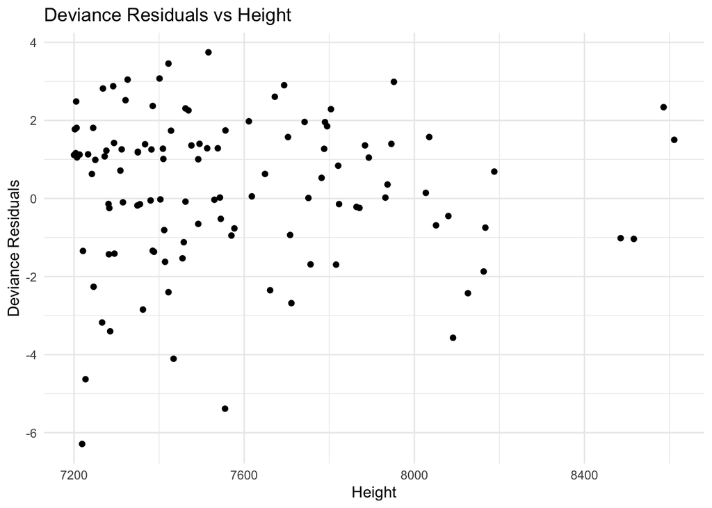

```r
library(ggplot2)
deviances <- residuals(bin1, type = "deviance")

# Plot height
ggplot(mount, aes(x = height, y = deviances)) +
  geom_point() +
  labs(title = "Deviance Residuals vs Height", x = "Height", y = "Deviance Residuals") +
  theme_minimal()
```

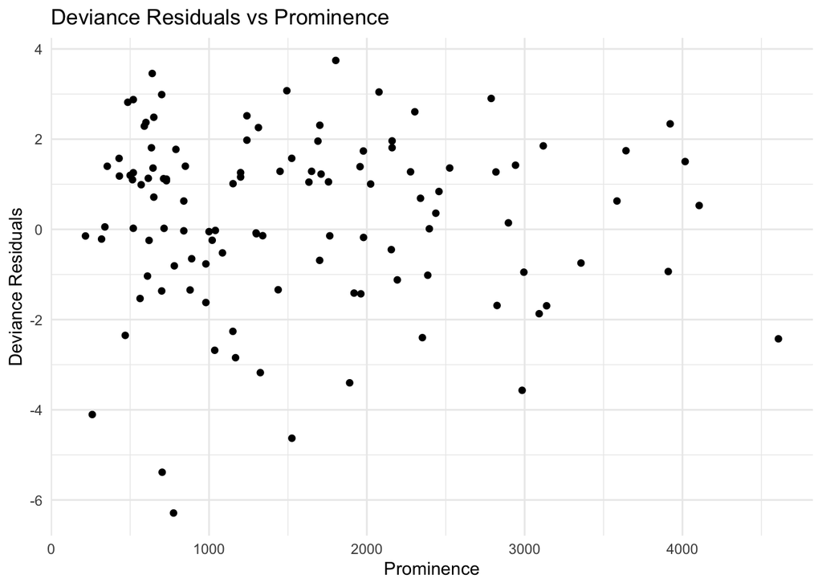

```r
# Plot prominence
ggplot(mount, aes(x = prominence, y = deviances)) +
  geom_point() +
  labs(title = "Deviance Residuals vs Prominence", x = "Prominence", y = "Deviance Residuals") +
  theme_minimal()
```

#### Description and interpretation:

- For height: The deviance residuals are scattered quite evenly around the x-axis. There are more stronger deviances in the negative direction than positive. I would not say that there is a funnel shape in the plot, but the data for mountains over 8200 meters is sparse, so it’s hard to evaluate.
- For prominence: For prominence as well, the deviance residuals are scattered quite evenly around the x-axis with no clear pattern recognisable.
- The deviance residuals indicate a good model fit or at least that there is no problem with the fit.

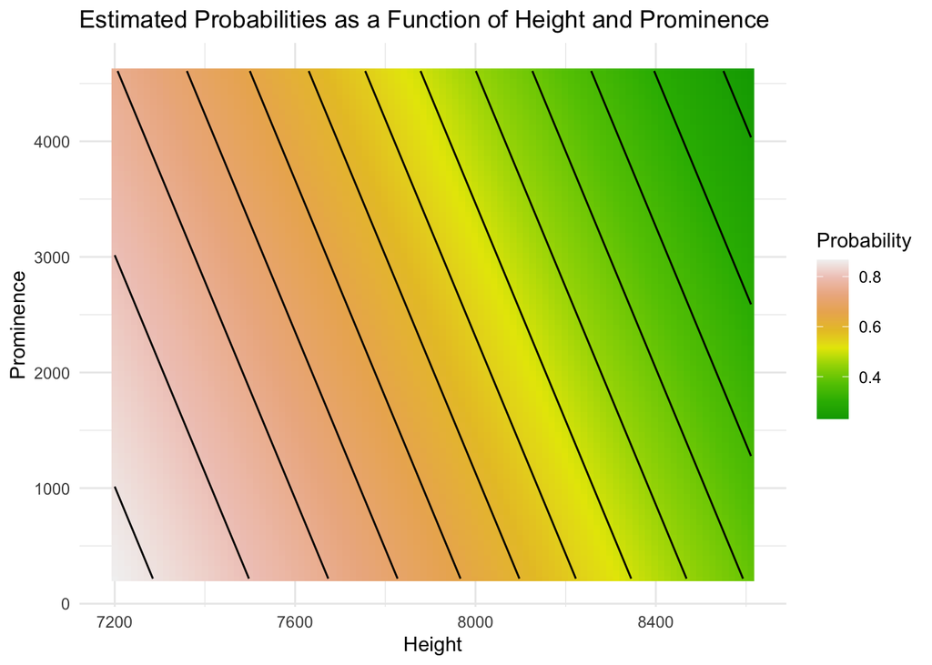

```r
# loglink???

height_seq <- seq(min(mount$height), max(mount$height), length.out = 100)
prominence_seq <- seq(min(mount$prominence), max(mount$prominence), length.out = 100)

# Create a data frame of all combinations of height and prominence
grid_data <- expand.grid(height = height_seq, prominence = prominence_seq)

# Predict the probabilities for the grid data
grid_data$prob <- predict(bin1, newdata = grid_data, type = "response")

ggplot(grid_data, aes(x = height, y = prominence, fill = prob)) +
  geom_raster() +
  geom_contour(aes(z = prob), color = "black") +
  scale_fill_gradientn(colours = terrain.colors(10)) +
  labs(title = "Estimated Probabilities as a Function of Height and Prominence",
       x = "Height", y = "Prominence", fill = "Probability") +
  theme_minimal()
```

#### Interpretation:

- The plot shows that the estimated probabilities for smaller mountains with smaller prominence are higher than for the higher ones with higher prominence.
- This is logical as it is harder to get up a larger mountain.
- The prominence seems to have less influence per meter. As the rate of change (especially when thinking of the differently scaled axis) is smaller for prominence than for height. This means the height has a bigger influence on whether or not one reaches a mountain summit.

## d)

CI formula: $CI_{\eta} = \left( \hat{\eta} - 1.96 \cdot \text{SE}(\eta), \hat{\eta} + 1.96 \cdot \text{SE}(\eta) \right)$

```r
everest<- data.frame(height = 8848, prominence = 8848)
eta_everest <- predict(bin1, newdata = everest, type = "link", se.fit = TRUE)
prob_everest <- predict(bin1, newdata = everest, type = "response")

# Confidence interval for eta
eta_L <- eta_everest$fit - 1.96 * eta_everest$se.fit
eta_H <- eta_everest$fit + 1.96 * eta_everest$se.fit

# Transform back to probability
prob_L <- 1 / (1 + exp(-eta_L))
prob_H <- 1 / (1 + exp(-eta_H))

cat('probability for Mount Everest', prob_everest, '\n')
```

```
## probability for Mount Everest 0.08917783
```

```r
cat('Confidence Interval:', prob_L, 'to', prob_H, '\n', '\n')
```

```
## Confidence Interval: 0.05486523 to 0.1417315
##
```

```r
chog <- data.frame(height = 7665, prominence = 1624)
eta_chog <- predict(bin1, newdata = chog, type = "link", se.fit = TRUE)
prob_chog <- predict(bin1, newdata = chog, type = "response")

# Confidence interval for eta
eta_L_chog <- eta_chog$fit - 1.96 * eta_everest$se.fit
eta_H_chog <- eta_chog$fit + 1.96 * eta_everest$se.fit

# Transform back to probability
prob_L_chog <- 1 / (1 + exp(-eta_L_chog))
prob_H_chog <- 1 / (1 + exp(-eta_H_chog))

cat('probability for Chogolisa', prob_chog, '\n')
```

```
## probability for Chogolisa 0.7042924
```

```r
cat('Confidence Interval:', prob_L_chog, 'to', prob_H_chog)
```

```
## Confidence Interval: 0.5854264 to 0.8006808
```

#### Reasonable?

- I would not say it is reasonable to model Mount Everest as the highest prominence in the data the model learned with was 4608 meters, which is way below the 8848 meters of Mount Everest. So, the model might fail in extrapolating to this high value of prominence.

```r
max(mount$prominence)
```

```
## [1] 4608
```

```r
min(mount$prominence)
```

```
## [1] 217
```

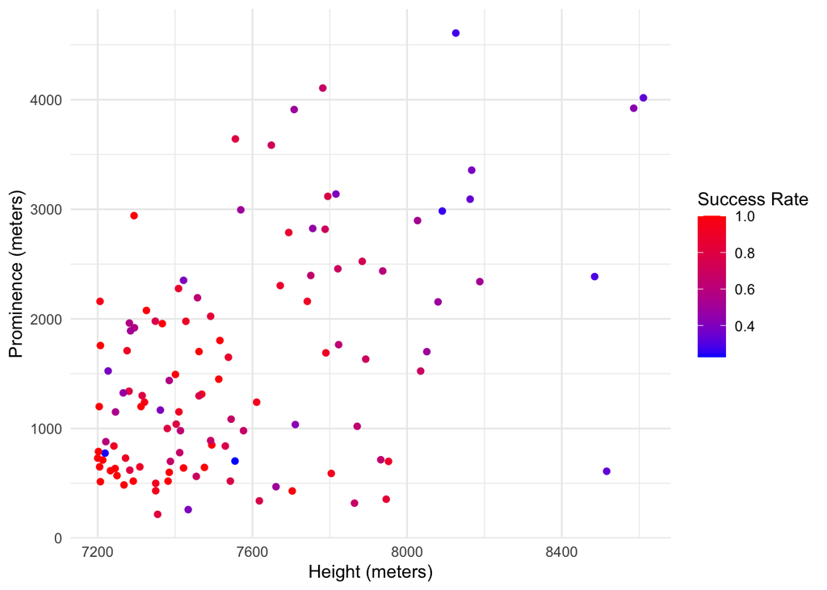

```r
ggplot(mount, aes(x = height, y = prominence, color = success / (success + fail))) +
  geom_point() +
  labs(
    x = "Height (meters)",
    y = "Prominence (meters)",
    color = "Success Rate"
  ) +
  scale_color_gradient(low = "blue", high = "red") + # Customize colors if desired
  theme_minimal() # Optional: for a cleaner theme
```

#### Chogolisa:

- The model underestimates the success probability with about 70% as it was historically about 90%.
- The CI interval is quite large which indicates a high uncertainty.
- The model might/should fit better for this value as it learned with values in this range, but Chogolisa has a combination of values which is quite rare (see visualisation above). So, maybe that is way the model does not fit the value accurately.

# Part 2: Poisson regression – Eliteserien 2023

## a)

```r
library(stats)
## With R function
max_goals = max(max(eliteserie$yh, na.rm = TRUE), max(eliteserie$ya, na.rm = TRUE))

goal_table <- matrix(0, nrow = max(eliteserie$yh, na.rm = TRUE)+1, ncol = max(eliteserie$ya, na.rm = TRUE)+1)

all_goals_home <- 0: max(eliteserie$yh, na.rm = TRUE)
all_goals_away <- 0: max(eliteserie$ya, na.rm = TRUE)

rownames(goal_table) <- paste("Home", all_goals_home)
colnames(goal_table) <- paste("Away", all_goals_away)


# iterate and add data
for (i in 1:nrow(eliteserie)) {
  if (!is.na(eliteserie$yh[i]) && !is.na(eliteserie$ya[i])) {
    home_goals <- eliteserie$yh[i]
    away_goals <- eliteserie$ya[i]

    goal_table[as.character(paste("Home", home_goals)), as.character(paste("Away", away_goals))] <-
      goal_table[as.character(paste("Home", home_goals)), as.character(paste("Away", away_goals))] + 1}
}
print(goal_table)
```

```
##        Away 0 Away 1 Away 2 Away 3 Away 4 Away 5 Away 6 Away 7
## Home 0     10     17      8      3      3      1      0      0
## Home 1     21     21     12      9      3      0      0      1
## Home 2      9     15     15      3      3      0      0      0
## Home 3      7      5      3      3      0      0      0      0
## Home 4      6      4      2      1      0      0      0      0
## Home 5      1      1      1      1      0      0      0      0
## Home 6      1      1      0      0      0      0      0      0
```

```r
# Chi-squared test of independence
goal_table_adj <- goal_table + 0.5
chi_test <- chisq.test(goal_table_adj)
print(chi_test)
```

```
##
##  Pearson's Chi-squared test
##
## data:  goal_table_adj
## X-squared = 21.942, df = 42, p-value = 0.9955
```

#### Interpretation:

The Pearson Chi Square test is not significant, so we keep the H0 that there is no dependency between the variables. For the model this means, there is no evidence against the independence and we can keep our assumptions that home goals and away goals are independent.

## b)

```r
library(dplyr)
```

```r
unique_clubs <- unique(c(eliteserie$home, eliteserie$away))

# data frame empty
clubs_df <- data.frame(
  club = unique_clubs,
  points = 0,
  no_goals = 0
)

for(i in 1:nrow(eliteserie)) {

  if (!is.na(eliteserie$yh[i]) && !is.na(eliteserie$ya[i])) {
    # Update no of goals
    clubs_df$no_goals[clubs_df$club == eliteserie$home[i]] <-
      clubs_df$no_goals[clubs_df$club == eliteserie$home[i]] + eliteserie$yh[i]

    clubs_df$no_goals[clubs_df$club == eliteserie$away[i]] <-
      clubs_df$no_goals[clubs_df$club == eliteserie$away[i]] + eliteserie$ya[i]

    # Update points based on match results
    # draw
    if (eliteserie$yh[i] == eliteserie$ya[i]) {
      clubs_df$points[clubs_df$club == eliteserie$home[i]] <-
        clubs_df$points[clubs_df$club == eliteserie$home[i]] + 1
      clubs_df$points[clubs_df$club == eliteserie$away[i]] <-
        clubs_df$points[clubs_df$club == eliteserie$away[i]] + 1

    }
    # Home team wins
    else if (eliteserie$yh[i] > eliteserie$ya[i]) {
      clubs_df$points[clubs_df$club == eliteserie$home[i]] <-
        clubs_df$points[clubs_df$club == eliteserie$home[i]] + 3

    }
    # Away team wins
    else {
      clubs_df$points[clubs_df$club == eliteserie$away[i]] <-
        clubs_df$points[clubs_df$club == eliteserie$away[i]] + 3
    }
  }
}
clubs_df <- clubs_df %>% arrange(desc(points), desc(no_goals))
print(clubs_df)
```

```
##                  club points no_goals
## 1          Bodø/Glimt     53       57
## 2               Brann     46       42
## 3               Molde     44       54
## 4              Viking     43       46
## 5           Rosenborg     40       40
## 6         Fredrikstad     40       32
## 7                KFUM     33       30
## 8              HamKam     29       30
## 9              Tromsø     28       28
## 10       Strømsgodset     28       28
## 11       Sarpsborg 08     26       33
## 12       Kristiansund     26       27
## 13          Haugesund     23       23
## 14 Sandefjord Fotball     22       31
## 15                Odd     22       22
## 16         Lillestrøm     21       26
```

## c)

```r
set.seed(7)
# helper function loglikelihood
loglik <- function(par, args) {
    y <- args$y  # observed counts
    x <- args$x  # predictor matrix

    # Linear predictor: eta = X * beta
    eta <- x %*% par

    # Log-likelihood for Poisson regression (log link)
    res <- sum(y * eta - exp(eta))

    return(res)
}


# helper function gradient of loglikelihood
loglik_gr <- function(par, args) {
    y <- args$y  # observed counts
    x <- args$x  # predictor matrix

    eta <- x %*% par
    lambda_hat <- exp(eta)
    res <- t(x) %*% (y - lambda_hat)

    return(res)
}


myPoisson <- function(args){

  # random initial parameters
  init_params <- rnorm(args$n_param, mean = 0, sd = 1)

  opt <- optim(par = init_params,
          args = args,
          fn = loglik, # log likelihood function
          gr = loglik_gr, # gradient of loglink = score
          control = list(fnscale = -1), # maximise
          hessian = TRUE, # return
          method = "BFGS")

  betas <- data.frame(opt$par)
  rownames(betas) <- colnames(args$x)
  betas['Bodø/Glimt',1] <- 0
  betas <- betas[order(betas$opt.par, decreasing = TRUE), , drop = FALSE]


  return(list(opt, betas))

}

## prepare vector for ranking

eliteserie1 <- na.omit(eliteserie)

col_names =c('intercept', 'home', unique_clubs)
col_names
```

```
##  [1] "intercept"          "home"               "Odd"
##  [4] "Fredrikstad"        "Lillestrøm"         "Molde"
##  [7] "Rosenborg"          "Tromsø"             "Viking"
## [10] "KFUM"               "Bodø/Glimt"         "Kristiansund"
## [13] "HamKam"             "Haugesund"          "Sarpsborg 08"
## [16] "Strømsgodset"       "Brann"              "Sandefjord Fotball"
```

```r
X <- data.frame(matrix(0, nrow=382, ncol = 18))  # 384 rows, 18 columns
colnames(X) <- col_names  # Assign the column names


goals <- matrix(ncol=1, nrow=382)

colmap <- setNames(seq_along(colnames(X)), colnames(X))

for(i in 1:nrow(eliteserie1)){
  X[i, colmap["home"]] <- 1
  X[i, colmap["intercept"]] <- 1
  X[i, colmap[eliteserie1$home[i]]] <- 1
  X[i, colmap[eliteserie1$away[i]]] <- -1
  goals[i] <- eliteserie1$yh[i]


  X[i+191, colmap["intercept"]] <- 1
  X[i+191, colmap[eliteserie1$home[i]]] <- -1
  X[i+191, colmap[eliteserie1$away[i]]] <- 1
  goals[i+191] <- eliteserie1$ya[i]
}
X[,'Bodø/Glimt'] <- 0



## use myPoisson and create ranking
a <- myPoisson(list(y = as.matrix(goals), x = as.matrix(X), n_param = 18))
betas <-  a[[2]]
betas['intercept', 1]
```

```
## [1] 0.2311293
```

```r
opt <-  a[[1]]
print(betas)
```

```
##                       opt.par
## intercept           0.2311293
## home                0.1553390
## Bodø/Glimt          0.0000000
## Molde              -0.1354024
## Viking             -0.2517446
## Brann              -0.2921529
## Rosenborg          -0.4106447
## Fredrikstad        -0.4360976
## KFUM               -0.4415022
## HamKam             -0.4546664
## Tromsø             -0.5592364
## Sandefjord Fotball -0.5998536
## Kristiansund       -0.6158600
## Strømsgodset       -0.6187322
## Haugesund          -0.6742180
## Sarpsborg 08       -0.7130112
## Odd                -0.7458919
## Lillestrøm         -0.8171113
```

```r
## for comparison
summary(glm(goals ~ -1 + .,data=X, family = "poisson"))
```

```
##
## Call:
## glm(formula = goals ~ -1 + ., family = "poisson", data = X)
##
## Coefficients: (1 not defined because of singularities)
##                      Estimate Std. Error z value Pr(>|z|)
## intercept             0.23110    0.06433   3.592 0.000328 ***
## home                  0.15532    0.08567   1.813 0.069851 .
## Odd                  -0.74587    0.16551  -4.507 6.59e-06 ***
## Fredrikstad          -0.43610    0.16591  -2.629 0.008574 **
## Lillestrøm           -0.81707    0.16549  -4.937 7.92e-07 ***
## Molde                -0.13541    0.16254  -0.833 0.404799
## Rosenborg            -0.41061    0.16580  -2.477 0.013265 *
## Tromsø               -0.55920    0.16603  -3.368 0.000757 ***
## Viking               -0.25181    0.16148  -1.559 0.118901
## KFUM                 -0.44152    0.16273  -2.713 0.006663 **
## `Bodø/Glimt`               NA         NA      NA       NA
## Kristiansund         -0.61584    0.16401  -3.755 0.000173 ***
## HamKam               -0.45457    0.16223  -2.802 0.005080 **
## Haugesund            -0.67406    0.16203  -4.160 3.18e-05 ***
## `Sarpsborg 08`       -0.71304    0.16192  -4.404 1.06e-05 ***
## Strømsgodset         -0.61881    0.16204  -3.819 0.000134 ***
## Brann                -0.29222    0.16107  -1.814 0.069650 .
## `Sandefjord Fotball` -0.59992    0.16403  -3.657 0.000255 ***
## ---
## Signif. codes:  0 '***' 0.001 '**' 0.01 '*' 0.05 '.' 0.1 ' ' 1
##
## (Dispersion parameter for poisson family taken to be 1)
##
##     Null deviance: 549.63  on 382  degrees of freedom
## Residual deviance: 426.61  on 365  degrees of freedom
## AIC: 1161.4
##
## Number of Fisher Scoring iterations: 5
```

#### Comparison with ranking in b):

- There are some differences in the rankings with same places changed but overall the ranking is quite similar.
- The differences might be due to the added parameter home, which results in teams with many away goals having higher betas = more strength, because the away strength is entirely carried by the team strength.

#### Comparison to glm function:

- Same except for some decimals.
- This might be due to optimization method, which wasn’t Newton-Raphson but BFGS which is a quasi newton method, because optim does not Newton Raphson as option.

## d)

```r
simulation_list = list()

rownames(clubs_df) <- clubs_df$club
clubs_df <- clubs_df[, -which(names(clubs_df)=="club")]

for (i in 1:1000) {

  simulation_list <- append(simulation_list, list(clubs_df))
}



Unplayed <- eliteserie[is.na(eliteserie$yh), c("home", "away")]

intercept <- betas["intercept",1]
home_advantage <- betas["home", 1]

for(j in 1:nrow(Unplayed)){
  home_team <- betas[Unplayed$home[j], 1]
  away_team <- betas[Unplayed$away[j], 1]
  lambda_home <- exp(intercept + home_advantage + home_team - away_team)
  lambda_away <- exp(intercept + away_team - home_team)

    # Simulate the number of goals using the Poisson distribution
  goals_home <- rpois(1000, lambda_home)
  goals_away <- rpois(1000, lambda_away)

  for(i in seq(1:1000)){
    gh <- goals_home[i]
    ga <- goals_away[i]

    #print(length(simulation_list[[i]][home_team, "no_goals"])+3)
    simulation_list[[i]][Unplayed$home[j], "no_goals"] <- simulation_list[[i]][Unplayed$home[j], "no_goals"] + gh
    simulation_list[[i]][Unplayed$away[j], "no_goals"] <- simulation_list[[i]][Unplayed$away[j], "no_goals"] + ga
    if (gh == ga) {
      ph <- 1
      pa <- 1
    } else if (gh > ga) {
      ph <- 3
      pa <- 0
    } else {
      ph <- 0
      pa <- 3
    }
    simulation_list[[i]][Unplayed$away[j], "points"] <- simulation_list[[i]][Unplayed$away[j], "points"] + pa
    simulation_list[[i]][Unplayed$home[j], "points"] <- simulation_list[[i]][Unplayed$home[j], "points"] + ph
  }
}

#order and get rank
for(i in seq(1:1000)){
  simulation_list[[i]] <- simulation_list[[i]] %>% arrange(desc(points), desc(no_goals))
  simulation_list[[i]]["ranking"] <- seq(1,16)
}

# Initialize results data frame
results <- data.frame(city = unique_clubs, mean_points = NA, var_points = NA, ci_lower = NA, ci_upper = NA, rank_list = NA, win_ratio = NA, final_points = NA)
results$rank_list <- vector("list", length(unique_clubs))
results$final_points <- vector("list", length(unique_clubs))

# Confidence level
alpha <- 0.05
z <- qnorm(1 - alpha/2)


for (city in unique_clubs) {
  # Extract points for the city across all simulations
  points_vector <- sapply(simulation_list, function(df) df[city, "points"])
  rank_vector <-  sapply(simulation_list, function(df) df[city, "ranking"])
  # Calculate mean and variance
  mean_val <- mean(points_vector, na.rm = TRUE)
  var_val <- var(points_vector, na.rm = TRUE)

  # Calculate standard error
  n <- sum(!is.na(points_vector))  # Number of non-NA values
  se <- sqrt(var_val / n)

  # Calculate confidence interval
  ci_lower <- mean_val - z * se
  ci_upper <- mean_val + z * se

  # Store the results
  results[results$city == city, "mean_points"] <- mean_val
  results[results$city == city, "var_points"] <- var_val
  results[results$city == city, "ci_lower"] <- ci_lower
  results[results$city == city, "ci_upper"] <- ci_upper
  results$rank_list[[which(results$city == city)]] <- rank_vector
  results[results$city == city, "win_ratio"] <- sum(rank_vector==1)/1000
  results$final_points[[which(results$city == city)]] <- points_vector

}
results[,c('mean_points', 'var_points', 'ci_lower', 'ci_upper','win_ratio')]
```

```
##    mean_points var_points ci_lower ci_upper win_ratio
## 1       27.044   7.683748 26.87220 27.21580     0.000
## 2       49.286   8.352557 49.10687 49.46513     0.000
## 3       25.930   7.164264 25.76410 26.09590     0.000
## 4       56.068   8.974350 55.88233 56.25367     0.010
## 5       48.733   9.691402 48.54005 48.92595     0.000
## 6       35.195   9.198173 35.00703 35.38297     0.000
## 7       55.068   8.682058 54.88538 55.25062     0.000
## 8       42.915  10.055831 42.71846 43.11154     0.000
## 9       66.419   6.950389 66.25560 66.58240     0.988
## 10      33.805  10.491466 33.60425 34.00575     0.000
## 11      38.292  10.497233 38.09119 38.49281     0.000
## 12      29.613   8.049280 29.43716 29.78884     0.000
## 13      30.853   7.368760 30.68475 31.02125     0.000
## 14      34.433   8.868379 34.24843 34.61757     0.000
## 15      56.103   9.469861 55.91227 56.29373     0.002
## 16      30.350   9.853353 30.15545 30.54455     0.000
```

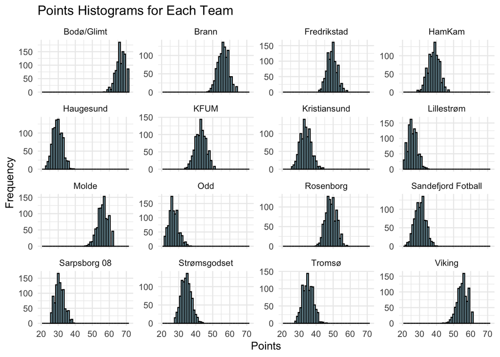

```r
#rownames(simulated_df) <- unique_clubs
# Load necessary libraries
library(ggplot2)
library(dplyr)
library(tidyr)

# Assuming `results` is your data frame with `rank_list` column containing the rankings as lists
## points histogram
# Step 1: Convert the `rank_list` column into long format
rankings_long <- results %>%
  rowwise() %>%  # Operate row-wise
  mutate(final_points = list(as.data.frame(final_points))) %>%  # Convert rank_list to data frame format
  unnest(final_points)  # Unnest the list-column into long format

# Step 2: Create the facet-wrapped histograms
ggplot(rankings_long, aes(x = final_points)) +
  geom_histogram(binwidth = 1, fill = "lightblue", color = "black") +
  facet_wrap(~ city, scales = "free_y") +  # Facet by team (city) with free y-scale
  labs(title = "Points Histograms for Each Team", x = "Points", y = "Frequency") +
  theme_minimal()
```

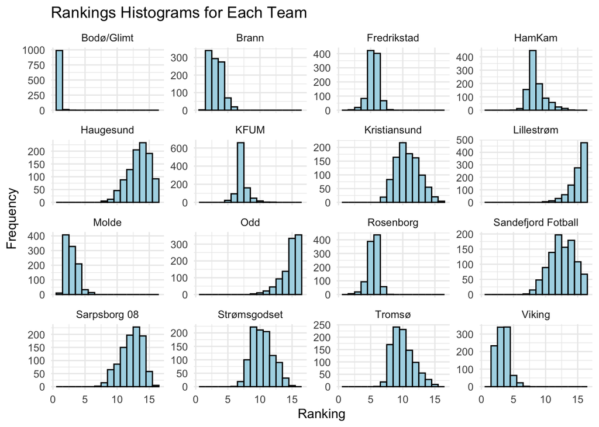

```r
## ranking histogram
rankings_long <- results %>%
  rowwise() %>%  # Operate row-wise
  mutate(rank_list = list(as.data.frame(rank_list))) %>%  # Convert rank_list to data frame format
  unnest(rank_list)  # Unnest the list-column into long format

# Step 2: Create the facet-wrapped histograms
ggplot(rankings_long, aes(x = rank_list)) +
  geom_histogram(binwidth = 1, fill = "lightblue", color = "black") +
  facet_wrap(~ city, scales = "free_y") +  # Facet by team (city) with free y-scale
  labs(title = "Rankings Histograms for Each Team", x = "Ranking", y = "Frequency") +
  theme_minimal()
```

- The lower ranked teams have higher variance in their rankings. This could be due to fact that they have a lower number of final points where smaller difference in points make a higher difference in rank. Also, they might win some games against other bad teams and lose some.
- Bodo has really stable ranking. So, it seems to be pretty good.
- The histograms for the final points are distributed almost normally as they are a sum.
- Also, the final points histograms mirror the ranking histogram, which is not surprising as the ranking is built with the final points.

#### comparison to real ranking in 2023 and discussion:

```r
results[order(-results$mean_points),c("city", "mean_points")]
```

```
##                  city mean_points
## 9          Bodø/Glimt      66.419
## 15              Brann      56.103
## 4               Molde      56.068
## 7              Viking      55.068
## 2         Fredrikstad      49.286
## 5           Rosenborg      48.733
## 8                KFUM      42.915
## 11             HamKam      38.292
## 6              Tromsø      35.195
## 14       Strømsgodset      34.433
## 10       Kristiansund      33.805
## 13       Sarpsborg 08      30.853
## 16 Sandefjord Fotball      30.350
## 12          Haugesund      29.613
## 1                 Odd      27.044
## 3          Lillestrøm      25.930
```

```r
clubs_df
```

```
##                    points no_goals
## Bodø/Glimt             53       57
## Brann                  46       42
## Molde                  44       54
## Viking                 43       46
## Rosenborg              40       40
## Fredrikstad            40       32
## KFUM                   33       30
## HamKam                 29       30
## Tromsø                 28       28
## Strømsgodset           28       28
## Sarpsborg 08           26       33
## Kristiansund           26       27
## Haugesund              23       23
## Sandefjord Fotball     22       31
## Odd                    22       22
## Lillestrøm             21       26
```

- The rankings are pretty similar, which is not surprising as our predictions are based on this data.
- Slight deviations might be due to the outstanding games still: If our data contains a team which has already faced bodo two times, it may have a lower team strength score than a team who has played only once against bodo so far (since most teams loose against bodo).